# Chapter5

Henrik Husberg

21.02 2017

# Chapter 5 - Dimensionality reduction techniques

## PCA

This weeks exercises are all about dimension reductoin. This is very interesting for me because I’ve been using confirmatory factor analysis in my own research, and I’ve dabbled a little in PLS Path Modeling on my spare time. So let’s see if I can make sense of Principal Component Analysis and Multiple Correspondence Analysis.

First we’ll load the ‘human’ data frame and look at the structure and dimension of it.

```r
human <- read.csv(file = "./data/human.csv", row.names = 1)
str(human)
```

```
## 'data.frame':    155 obs. of  8 variables:
##  $ sec_ed_F2M: num  1.007 0.997 0.983 0.989 0.969 ...
##  $ labour_F2M: num  0.891 0.819 0.825 0.884 0.829 ...
##  $ eduexp    : num  17.5 20.2 15.8 18.7 17.9 16.5 18.6 16.5 15.9 19.2 ...
##  $ lifeexp   : num  81.6 82.4 83 80.2 81.6 80.9 80.9 79.1 82 81.8 ...
##  $ gni       : int  64992 42261 56431 44025 45435 43919 39568 52947 42155 32689 ...
##  $ matmort   : int  4 6 6 5 6 7 9 28 11 8 ...
##  $ ado_birth : num  7.8 12.1 1.9 5.1 6.2 3.8 8.2 31 14.5 25.3 ...
##  $ rep_parl  : num  39.6 30.5 28.5 38 36.9 36.9 19.9 19.4 28.2 31.4 ...
```

```r
dim(human)
```

```
## [1] 155   8
```

The data is taken from the Human Development Report 2015 which has been collected from different sources (see [this pdf](http://hdr.undp.org/sites/default/files/hdr2015_technical_notes.pdf) for more info.)

Here’s a short description of the variables included:

- **sec_edF2M:** ratio of proportions of females/males with at least secondary education
- **labour_F2M:** ratio of proportions of females/males in labour force
- **eduexp:** expected years of schooling
- **lifeexp:** life expectancy at birth
- **gni:** gross national income per capita
- **matmort:** maternal mortality ratio
- **ado_birth:** adolescent birth rate
- **rep_parl:** percentage of female representatives in parliament

Here’s a graphical overview of the variables:

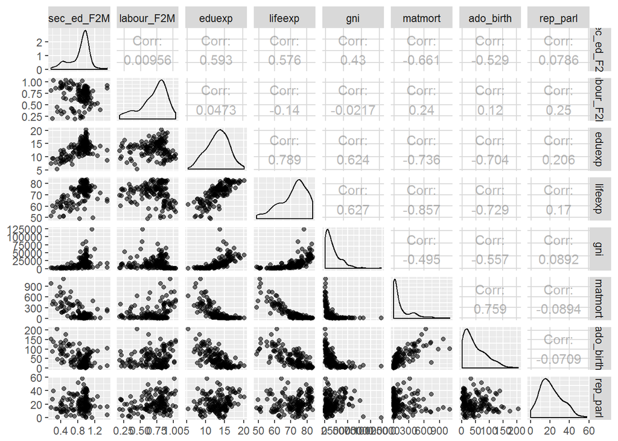

```r
library(GGally)
library(ggplot2)
p <- ggpairs(human, mapping = aes(alpha = 0.3), lower = list(combo = wrap("facethist", bins = 20)))
p
```

```r
summary(human)
```

```
##    sec_ed_F2M       labour_F2M         eduexp         lifeexp
##  Min.   :0.1717   Min.   :0.1857   Min.   : 5.40   Min.   :49.00
##  1st Qu.:0.7264   1st Qu.:0.5984   1st Qu.:11.25   1st Qu.:66.30
##  Median :0.9375   Median :0.7535   Median :13.50   Median :74.20
##  Mean   :0.8529   Mean   :0.7074   Mean   :13.18   Mean   :71.65
##  3rd Qu.:0.9968   3rd Qu.:0.8535   3rd Qu.:15.20   3rd Qu.:77.25
##  Max.   :1.4967   Max.   :1.0380   Max.   :20.20   Max.   :83.50
##       gni            matmort         ado_birth         rep_parl
##  Min.   :   581   Min.   :   1.0   Min.   :  0.60   Min.   : 0.00
##  1st Qu.:  4198   1st Qu.:  11.5   1st Qu.: 12.65   1st Qu.:12.40
##  Median : 12040   Median :  49.0   Median : 33.60   Median :19.30
##  Mean   : 17628   Mean   : 149.1   Mean   : 47.16   Mean   :20.91
##  3rd Qu.: 24512   3rd Qu.: 190.0   3rd Qu.: 71.95   3rd Qu.:27.95
##  Max.   :123124   Max.   :1100.0   Max.   :204.80   Max.   :57.50
```

From these we can see that gni and matmort are heavily positively skewed. There are some notable correlations between the variables. For example a rather obvious strong negative correlation between life expectancy and maternal mortality, education coorrelates negatively with adolescent brith rate and gross national income has a positive correlation with education but a negative correlation with maternal mortality. What’s maybe more interesting is what looks like a lack of a significant correlation between for example ratio of females to males with secondary education and female parliamentary representation.

From the summary we can also see that the variables have very different scales, with some variables being ratios and other being percentages (eg. rep_parl) or years (eg. lifeexp).

Now well run principal component analysis (PCA) in order to find the components that capture the most of the variance.

Next we’ll do a principal component analysis on this unstandardized data and visualize the results with a biplot:

```r
pca_human <- prcomp(human)
pca_human
```

```
## Standard deviations:
## [1] 1.854416e+04 1.855219e+02 2.518701e+01 1.145441e+01 3.766241e+00
## [6] 1.565912e+00 1.912052e-01 1.591112e-01
##
## Rotation:
##                      PC1           PC2           PC3           PC4
## sec_ed_F2M -5.607472e-06  0.0006713951 -3.412027e-05 -2.736326e-04
## labour_F2M  2.331945e-07 -0.0002819357  5.302884e-04 -4.692578e-03
## eduexp     -9.562910e-05  0.0075529759  1.427664e-02 -3.313505e-02
## lifeexp    -2.815823e-04  0.0283150248  1.294971e-02 -6.752684e-02
## gni        -9.999832e-01 -0.0057723054 -5.156742e-04  4.932889e-05
## matmort     5.655734e-03 -0.9916320120  1.260302e-01 -6.100534e-03
## ado_birth   1.233961e-03 -0.1255502723 -9.918113e-01  5.301595e-03
## rep_parl   -5.526460e-05  0.0032317269 -7.398331e-03 -9.971232e-01
##                      PC5           PC6           PC7           PC8
## sec_ed_F2M -0.0022935252  2.180183e-02  6.998623e-01  7.139410e-01
## labour_F2M  0.0022190154  3.264423e-02  7.132267e-01 -7.001533e-01
## eduexp      0.1431180282  9.882477e-01 -3.826887e-02  7.776451e-03
## lifeexp     0.9865644425 -1.453515e-01  5.380452e-03  2.281723e-03
## gni        -0.0001135863 -2.711698e-05 -8.075191e-07 -1.176762e-06
## matmort     0.0266373214  1.695203e-03  1.355518e-04  8.371934e-04
## ado_birth   0.0188618600  1.273198e-02 -8.641234e-05 -1.707885e-04
## rep_parl   -0.0716401914 -2.309896e-02 -2.642548e-03  2.680113e-03
```

```r
summary(pca_human)
```

```
## Importance of components:
##                              PC1      PC2   PC3   PC4   PC5   PC6    PC7
## Standard deviation     1.854e+04 185.5219 25.19 11.45 3.766 1.566 0.1912
## Proportion of Variance 9.999e-01   0.0001  0.00  0.00 0.000 0.000 0.0000
## Cumulative Proportion  9.999e-01   1.0000  1.00  1.00 1.000 1.000 1.0000
##                           PC8
## Standard deviation     0.1591
## Proportion of Variance 0.0000
## Cumulative Proportion  1.0000
```

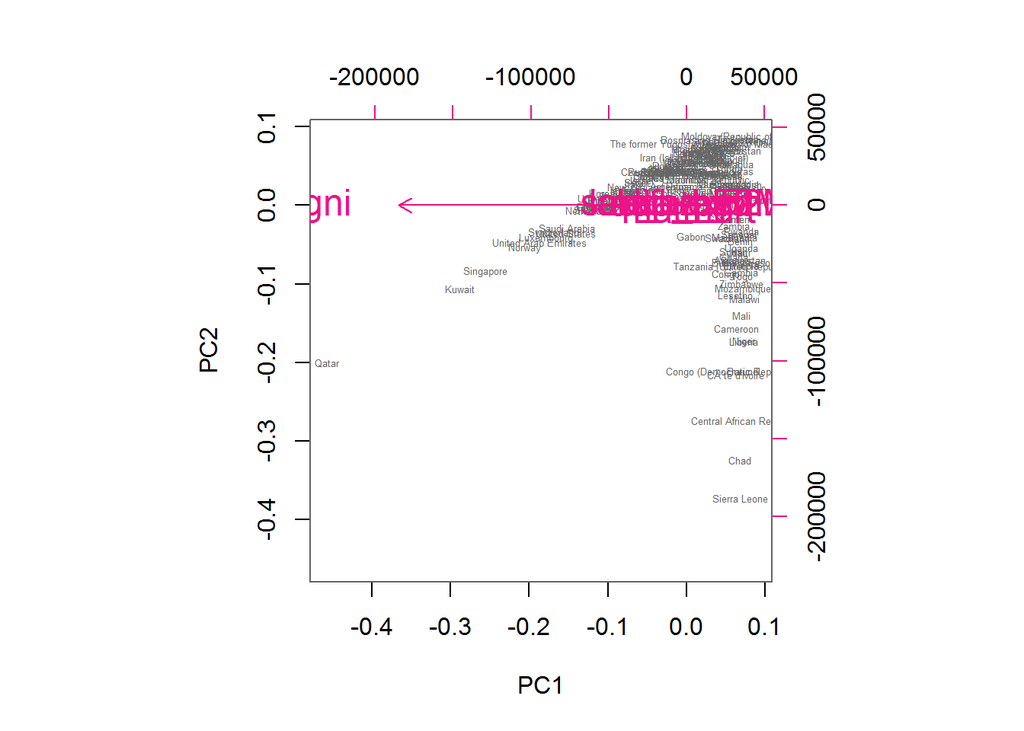

```r
biplot(pca_human, choices = 1:2, cex = c(0.4, 1.5), col = c("grey40", "deeppink2"))
```

This biplot suggests that almost all the variance is captured by one variable: the gross national income per capita, *(gni)*.

Now we’ll do this again using standardized values for all our variables:

```r
human_std <- scale(human)
summary(human_std)
```

```
##    sec_ed_F2M        labour_F2M          eduexp           lifeexp
##  Min.   :-2.8189   Min.   :-2.6247   Min.   :-2.7378   Min.   :-2.7188
##  1st Qu.:-0.5233   1st Qu.:-0.5484   1st Qu.:-0.6782   1st Qu.:-0.6425
##  Median : 0.3503   Median : 0.2316   Median : 0.1140   Median : 0.3056
##  Mean   : 0.0000   Mean   : 0.0000   Mean   : 0.0000   Mean   : 0.0000
##  3rd Qu.: 0.5958   3rd Qu.: 0.7350   3rd Qu.: 0.7126   3rd Qu.: 0.6717
##  Max.   : 2.6646   Max.   : 1.6632   Max.   : 2.4730   Max.   : 1.4218
##       gni             matmort          ado_birth          rep_parl
##  Min.   :-0.9193   Min.   :-0.6992   Min.   :-1.1325   Min.   :-1.8203
##  1st Qu.:-0.7243   1st Qu.:-0.6496   1st Qu.:-0.8394   1st Qu.:-0.7409
##  Median :-0.3013   Median :-0.4726   Median :-0.3298   Median :-0.1403
##  Mean   : 0.0000   Mean   : 0.0000   Mean   : 0.0000   Mean   : 0.0000
##  3rd Qu.: 0.3712   3rd Qu.: 0.1932   3rd Qu.: 0.6030   3rd Qu.: 0.6127
##  Max.   : 5.6890   Max.   : 4.4899   Max.   : 3.8344   Max.   : 3.1850
```

```r
pca_human_std <- prcomp(human_std)
pca_human_std
```

```
## Standard deviations:
## [1] 2.0708380 1.1397204 0.8750485 0.7788630 0.6619563 0.5363061 0.4589994
## [8] 0.3222406
##
## Rotation:
##                    PC1         PC2         PC3         PC4        PC5
## sec_ed_F2M -0.35664370  0.03796058 -0.24223089  0.62678110 -0.5983585
## labour_F2M  0.05457785  0.72432726 -0.58428770  0.06199424  0.2625067
## eduexp     -0.42766720  0.13940571 -0.07340270 -0.07020294  0.1659678
## lifeexp    -0.44372240 -0.02530473  0.10991305 -0.05834819  0.1628935
## gni        -0.35048295  0.05060876 -0.20168779 -0.72727675 -0.4950306
## matmort     0.43697098  0.14508727 -0.12522539 -0.25170614 -0.1800657
## ado_birth   0.41126010  0.07708468  0.01968243  0.04986763 -0.4672068
## rep_parl   -0.08438558  0.65136866  0.72506309  0.01396293 -0.1523699
##                    PC6         PC7         PC8
## sec_ed_F2M  0.17713316  0.05773644  0.16459453
## labour_F2M -0.03500707 -0.22729927 -0.07304568
## eduexp     -0.38606919  0.77962966 -0.05415984
## lifeexp    -0.42242796 -0.43406432  0.62737008
## gni         0.11120305 -0.13711838 -0.16961173
## matmort     0.17370039  0.35380306  0.72193946
## ado_birth  -0.76056557 -0.06897064 -0.14335186
## rep_parl    0.13749772  0.00568387 -0.02306476
```

```r
summary(pca_human_std)
```

```
## Importance of components:
##                           PC1    PC2     PC3     PC4     PC5     PC6
## Standard deviation     2.0708 1.1397 0.87505 0.77886 0.66196 0.53631
## Proportion of Variance 0.5361 0.1624 0.09571 0.07583 0.05477 0.03595
## Cumulative Proportion  0.5361 0.6984 0.79413 0.86996 0.92473 0.96069
##                            PC7     PC8
## Standard deviation     0.45900 0.32224
## Proportion of Variance 0.02634 0.01298
## Cumulative Proportion  0.98702 1.00000
```

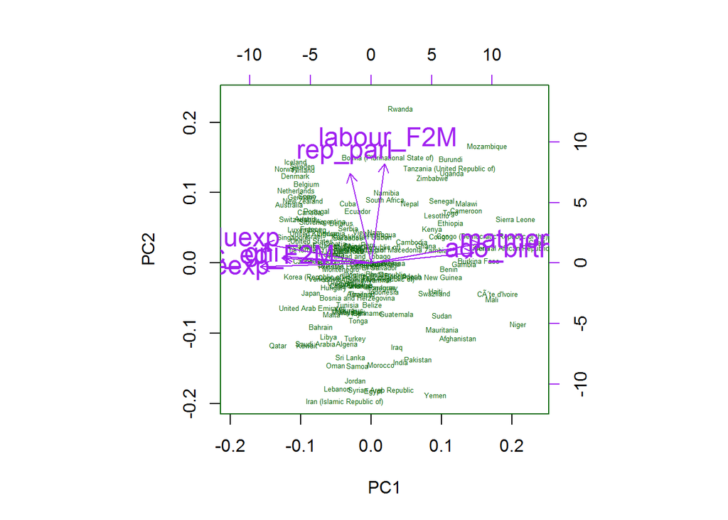

```r
biplot(pca_human_std, choices = 1:2, cex = c(0.4, 1.5), col = c("darkgreen", "purple"))
```

Ok, so obviously the variables have to be on the same scale in order for us to be able to interpret the results of PCA properly. In the first instance, with the unstandardized variables, all the variance seemed to be capured by *gni*. Because PCA assumes that larger variance = more important and *gni* is measured in $ and ranging from 581 to 123124, this is why it is assigned way too much weight in the unstandardized PCA.

Ok, so back to our standardized biplot. The first two components explain 53,6% and 16,2% of the variance in our datamatrix, or 69,9% together. PC1 consists of positive loadings by maternal mortality and adolescent birth as well as negative loadings of gross national income, expected education, life expectancy and ratio of females to males with at least secondary education. PC2 consists of positive loadings by female parliamentary representation and ratio of females to males in labour. Roughly speaking these could be interpreted as a component representing “socioeconomic equality” (PC1) and one component for “gender equality” (PC2). So about 70% of the variance between countries could be explained by these two dimensions.

## MCA

Next, we’ll have a look at the *tea* dataset from Factominer.

```r
library(FactoMineR)
library(dplyr)
library(tidyr)
data(tea)
str(tea)
```

```
## 'data.frame':    300 obs. of  36 variables:
##  $ breakfast       : Factor w/ 2 levels "breakfast","Not.breakfast": 1 1 2 2 1 2 1 2 1 1 ...
##  $ tea.time        : Factor w/ 2 levels "Not.tea time",..: 1 1 2 1 1 1 2 2 2 1 ...
##  $ evening         : Factor w/ 2 levels "evening","Not.evening": 2 2 1 2 1 2 2 1 2 1 ...
##  $ lunch           : Factor w/ 2 levels "lunch","Not.lunch": 2 2 2 2 2 2 2 2 2 2 ...
##  $ dinner          : Factor w/ 2 levels "dinner","Not.dinner": 2 2 1 1 2 1 2 2 2 2 ...
##  $ always          : Factor w/ 2 levels "always","Not.always": 2 2 2 2 1 2 2 2 2 2 ...
##  $ home            : Factor w/ 2 levels "home","Not.home": 1 1 1 1 1 1 1 1 1 1 ...
##  $ work            : Factor w/ 2 levels "Not.work","work": 1 1 2 1 1 1 1 1 1 1 ...
##  $ tearoom         : Factor w/ 2 levels "Not.tearoom",..: 1 1 1 1 1 1 1 1 1 2 ...
##  $ friends         : Factor w/ 2 levels "friends","Not.friends": 2 2 1 2 2 2 1 2 2 2 ...
##  $ resto           : Factor w/ 2 levels "Not.resto","resto": 1 1 2 1 1 1 1 1 1 1 ...
##  $ pub             : Factor w/ 2 levels "Not.pub","pub": 1 1 1 1 1 1 1 1 1 1 ...
##  $ Tea             : Factor w/ 3 levels "black","Earl Grey",..: 1 1 2 2 2 2 2 1 2 1 ...
##  $ How             : Factor w/ 4 levels "alone","lemon",..: 1 3 1 1 1 1 1 3 3 1 ...
```

[output cut: 22 more lines]

```r
dim(tea)
```

```
## [1] 300  36
```

This is quite a large dataset with 36 variables. In order to make interpretations a bit easier I will only use a few of these:

- **Tea:** The kind of tea they drink

```r
summary(tea$Tea)
```

```
##     black Earl Grey     green
##        74       193        33
```

- **How:** How they prefer their tea

```r
summary(tea$How)
```

```
## alone lemon  milk other
##   195    33    63     9
```

- **sex:** Gender

```r
summary(tea$sex)
```

```
##   F   M
## 178 122
```

- **SPC:** Proxy for socioeconomic status

```r
summary(tea$SPC)
```

```
##     employee       middle   non-worker other worker       senior
##           59           40           64           20           35
##      student      workman
##           70           12
```

- **age:** Continuous variable for age

```r
summary(tea$age)
```

```
##    Min. 1st Qu.  Median    Mean 3rd Qu.    Max.
##   15.00   23.00   32.00   37.05   48.00   90.00
```

Now I’ll select these to keep:

```r
keep <- c("Tea", "How", "sex", "SPC", "age")
tea_shrt <- dplyr::select(tea, one_of(keep))
names(tea_shrt)
```

```
## [1] "Tea" "How" "sex" "SPC" "age"
```

Ok, now we know a bit about the variables. Now we’ll run the MCA, using our categorical variables as active and our continuous as a supplementary variable:

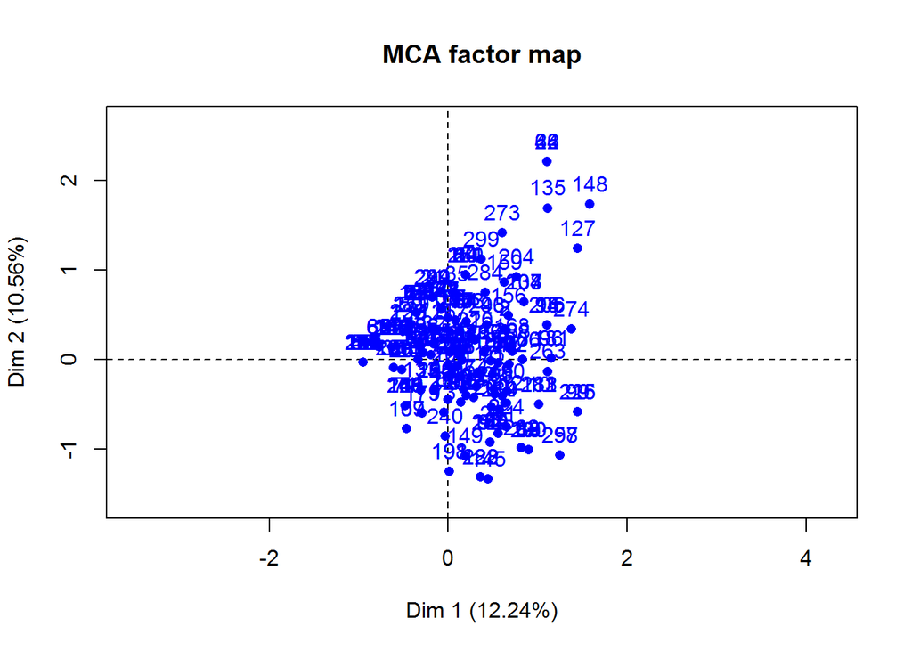

```r
tea_mca <- MCA(tea_shrt, quanti.sup=5, graph = FALSE)
plot(tea_mca, invisible = c("var"))
```

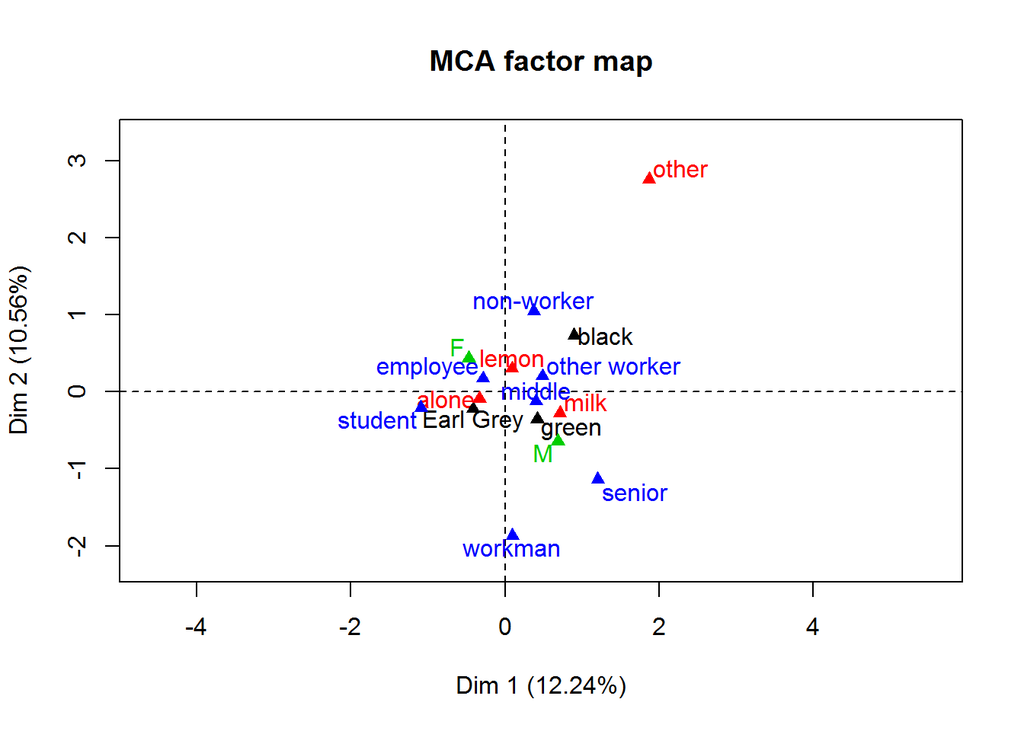

```r
plot(tea_mca, invisible = c("ind"), habillage="quali")
```

```r
summary(tea_mca)
```

```
##
## Call:
## MCA(X = tea_shrt, quanti.sup = 5, graph = FALSE)
##
##
## Eigenvalues
##                        Dim.1   Dim.2   Dim.3   Dim.4   Dim.5   Dim.6
## Variance               0.367   0.317   0.285   0.271   0.262   0.254
## % of var.             12.235  10.557   9.494   9.025   8.729   8.470
## Cumulative % of var.  12.235  22.793  32.286  41.311  50.041  58.510
##                        Dim.7   Dim.8   Dim.9  Dim.10  Dim.11  Dim.12
## Variance               0.249   0.238   0.222   0.202   0.171   0.163
## % of var.              8.311   7.918   7.402   6.743   5.692   5.424
## Cumulative % of var.  66.821  74.739  82.141  88.884  94.576 100.000
##
## Individuals (the 10 first)
##              Dim.1    ctr   cos2    Dim.2    ctr   cos2    Dim.3    ctr
## 1         |  0.683  0.424  0.162 | -0.052  0.003  0.001 | -0.527  0.325
## 2         |  0.638  0.370  0.116 |  0.344  0.125  0.034 | -0.730  0.624
## 3         | -0.303  0.083  0.023 |  0.147  0.023  0.006 |  0.419  0.206
## 4         | -0.476  0.206  0.155 | -0.514  0.278  0.181 | -0.385  0.174
## 5         | -0.144  0.019  0.012 | -0.345  0.125  0.072 |  0.126  0.019
## 6         | -0.476  0.206  0.155 | -0.514  0.278  0.181 | -0.385  0.174
## 7         |  0.472  0.202  0.088 | -0.929  0.908  0.341 | -0.401  0.188
## 8         |  0.638  0.370  0.116 |  0.344  0.125  0.034 | -0.730  0.624
## 9         |  0.904  0.742  0.245 | -1.011  1.077  0.307 | -0.601  0.423
## 10        |  1.014  0.933  0.326 | -0.504  0.268  0.081 | -0.536  0.336
##             cos2
## 1          0.096 |
## 2          0.152 |
## 3          0.045 |
## 4          0.102 |
## 5          0.010 |
## 6          0.102 |
## 7          0.063 |
## 8          0.152 |
## 9          0.108 |
## 10         0.091 |
##
## Categories (the 10 first)
```

[output cut: 18 more lines]

```
## other     -1.104  3.208  0.038 -3.357 |
## F         -0.002  0.000  0.000 -0.048 |
## M          0.003  0.000  0.000  0.048 |
## employee   0.404  2.824  0.040  3.460 |
##
## Categorical variables (eta2)
##             Dim.1 Dim.2 Dim.3
## Tea       | 0.329 0.178 0.322 |
## How       | 0.285 0.260 0.268 |
## sex       | 0.322 0.280 0.000 |
## SPC       | 0.532 0.548 0.549 |
##
## Supplementary continuous variable
##             Dim.1   Dim.2   Dim.3
## age       | 0.438 | 0.363 | 0.149 |
```

Now, looking first at the first *individuals* plot, there does not seem to be any clear groupings of individuals affecting the dimensions. When we look at the plot of *categories*, we can see that they are pretty much grouped around the center of the factor map. Three categories stand out a bit, the *other* category from the *How*-variable; the *workman* category from the *SPC*-variable and the *senior* category from the _SPC_variable. So it would seem that drinking your tea any other way than with lemon, milk or plain separates you from the pack. Likewise, workmen and (what I assume is) senior management seem to have tea habits that are different from most other.

Just for the fun of it, I’ll do one more plot where I color code individuals according to their preferred way of having their tea:

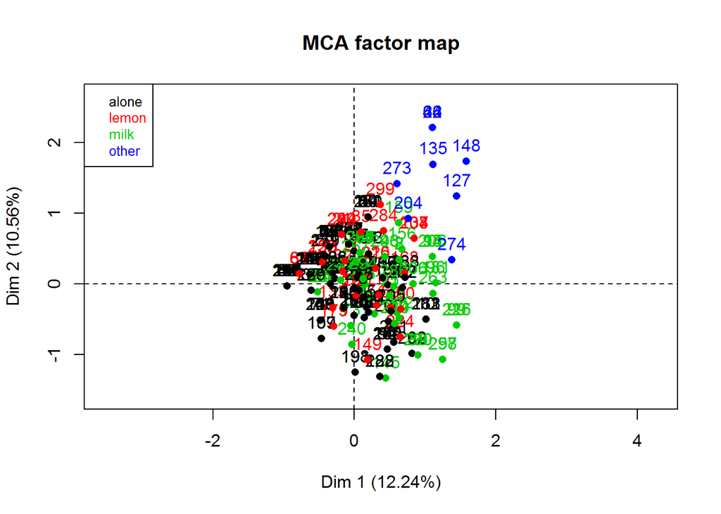

```r
plot(tea_mca, invisible = c("var"), habillage="How")
```